# Data Unstructured

## Training Objectives

This coursebook is intended for participants who have completed the preceding courses offered in the Basic Python & Introduction to Machine Learning. This is the last course, Data Unstructured Preparation.

The coursebook focuses on:

- **Text Preprocessing:**
  - Regular Expression for Text Cleansing
  - Stemming
  - Text Normalization
  - Stopwords Removal
  - Tokenization
  - Bag of Words

# Text Preprocessing

## Libraries

```python
# data analysis
import numpy as np
import pandas as pd

# data visualization
import matplotlib.pyplot as plt
# import seaborn as sns

# set seed
import random
random.seed(123)
np.random.seed(123)

# text processing
import re
import string
import nltk
from Sastrawi.Stemmer.StemmerFactory import StemmerFactory
from sklearn.model_selection import train_test_split

import pickle
```

## Load Dataset

In this section, let's perform sentiment classification on a dataset collected from Twitter regarding public sentiment towards a cellular service provider in Indonesia. The dataset has 2 sentiment classes: positive and negative. Before publishing, this dataset has been preprocessed as follows:

- Replacing the name/identity of the service provider with the PROVIDER_NAME tag
- Replacing the URL address with the URL tag
- Replacing user @username with USER_MENTION tag
- Replace product name with PRODUCT_NAME tag

> Reference data: [Rofiqoh, U., Perdana, R.S., & Fauzi, M.A. (2017)](https://github.com/rizalespe/Dataset-Sentimen-Analisis-Bahasa-Indonesia/blob/master/dataset_tweet_sentiment_cellular_service_provider.csv)

Read data `dataset_tweet_sentiment_cellular_service_provider.csv` using `pandas`

```python
df = pd.read_csv('data_input/dataset_tweet_sentiment_cellular_service_provider.csv').drop(columns='Id')
df.head()
```

|  | Sentiment | Text Tweet |
| --- | --- | --- |
| 0 | positive | <USER_MENTION> #BOIKOT_<PROVIDER_NAME> Gunakan... |
| 1 | positive | Saktinya balik lagi, alhamdulillah :v <PROVIDE... |
| 2 | negative | Selamat pagi <PROVIDER_NAME> bisa bantu kenap... |
| 3 | negative | Dear <PROVIDER_NAME> akhir2 ini jaringan data ... |
| 4 | negative | Selamat malam PENDUSTA <PROVIDER_NAME> |

**Discussion**

Looking at the data we have, what kind of text preprocessing do we need to do?

*Answer:*

> ...

## Text Preprocessing

Text preprocessing is a method to clean and prepare text data for learning by the model. Text data contains *noise* in various forms such as emoticons, punctuation marks, and different capitalization. Raw text data may contain unwanted or unimportant text, so machine learning models may produce unsatisfactory accuracy. We should not input raw data without preprocessing to build a model because **preprocessing text directly improves model performance**. In some cases, if we input raw data without preprocessing techniques, the model will get confused and give random results.

## Case Folding

*Case folding* is the process of uniformizing the text letters of all documents in the corpus. In text classification, case folding is generally done by homogenizing the document text in the corpus into *lowercase*. Lowercase folding is done to homogenize all letter shapes into lowercase letters so that there are no differences in words/terms at the time of feature extraction due to differences in letter shapes.

```python
df['text_lower'] = df['Text Tweet'].str.lower()
df.head()
```

|  | Sentiment | Text Tweet | text_lower |
| --- | --- | --- | --- |
| 0 | positive | <USER_MENTION> #BOIKOT_<PROVIDER_NAME> Gunakan... | <user_mention> #boikot_<provider_name> gunakan... |
| 1 | positive | Saktinya balik lagi, alhamdulillah :v <PROVIDE... | saktinya balik lagi, alhamdulillah :v <provide... |
| 2 | negative | Selamat pagi <PROVIDER_NAME> bisa bantu kenap... | selamat pagi <provider_name> bisa bantu kenap... |
| 3 | negative | Dear <PROVIDER_NAME> akhir2 ini jaringan data ... | dear <provider_name> akhir2 ini jaringan data ... |
| 4 | negative | Selamat malam PENDUSTA <PROVIDER_NAME> | selamat malam pendusta <provider_name> |

> **Tips:** In *text preprocessing*, the best practice is to **create a new column for each preprocessing**. This is very helpful when we want to refine the model evaluation with different preprocessing steps.

## Text Cleansing

*Text cleansing* consists of removing unnecessary data attributes such as certain punctuation marks (periods, commas, semicolons, quotes, etc.) and Uniform Resource Locator (URL) addresses. Specifically for Twitter data, some other attributes are not needed in the classification process, namely the RT (re-tweet) character and username (the name of the account that wrote the tweet). URLs, RT/mentions, and product names in this dataset have been replaced with tags.

> During text cleaning, it is common to use **regular expression (regex)**. A regex is a sequence of characters that define search patterns in text. Here's a reference to learn more about regex:
> - https://www.w3schools.com/python/python_regex.asp
> - https://regex101.com/

### Regular Expression

*Regular expression* or *regex* can be used to capture patterns in text. This *Tool* is very useful when we have some patterns that we want to replace with certain characters.

Suppose we want to replace all numbers with spaces. Numbers have a range from 0-9, so that we don't have to replace the numbers one by one, we can use regex.

*Regular expression* in Python can be done with the `re` library.

```python
import re # regex
```

#### Patterns

> The parentheses `[ ]` hold the patterns we want to search for

```python
re.sub('[-*/]', '.', 'masa setiap hari  pulsa berkurang 1500-2100 bisa 2-3*/hari')
```

```
'masa setiap hari  pulsa berkurang 1500.2100 bisa 2.3..hari'
```

We can also replace this with *empty string*

```python
re.sub('[-*/]', '', 'masa setiap hari  pulsa berkurang 1500-2100 bisa 2-3*/hari')
```

```
'masa setiap hari  pulsa berkurang 15002100 bisa 23hari'
```

> `\w` and `\W` match any *word character*

`\w` matches any alphanumeric word character. *Word characters* are uppercase and lowercase letters, numbers, and the underscore character ( _ ):

```python
re.sub('\w', '', 'masa setiap hari  pulsa berkurang 1500-2100 bisa 2-3*/hari')
```

```
'      -  -*/'
```

`\W` is the opposite. `\W` matches any character other than alphanumeric and *underscore*:

```python
re.sub('\W', '', 'masa setiap hari  pulsa berkurang 1500-2100 bisa 2-3*/hari')
```

```
'masasetiapharipulsaberkurang15002100bisa23hari'
```

```python
re.sub('[\\\]', '', "kano makan \\ sayur")
```

```
'kano makan  sayur'
```

> `\d` and `\D` match numbers (*digits*).

`\d` matches any number character. Conversely, `\D` matches any character that is not a number.

```python
re.sub('\d', '', 'masa setiap hari  pulsa berkurang 1500-2100 bisa 2-3*/hari')
```

```
'masa setiap hari  pulsa berkurang - bisa -*/hari'
```

```python
re.sub('[^ \d]', '', 'masa setiap hari  pulsa berkurang 1500-2100 bisa 2-3*/hari')
```

```
'      15002100  23'
```

> `\s` and `\S` match space and new line (*newline*) characters.

`\s` matches whitespace and *new line* characters:

```python
re.sub('\s', '', 'masa setiap hari  pulsa berkurang 1500-2100 bisa 2-3*/hari')
```

```
'masasetiapharipulsaberkurang1500-2100bisa2-3*/hari'
```

`\S` is the opposite of `\s`, so it matches any character other than spaces and *new line*:

```python
re.sub('\S', '', 'masa setiap hari  pulsa berkurang 1500-2100 bisa 2-3*/hari')
```

```
'        '
```

#### Quantifiers

A *Quantifier* indicates how many times a part must appear for a successful match.

> Plus (+) matches one or more repetitions.

```python
print(re.sub('\s', '/', 'masa setiap hari  pulsa berkurang 1500-2100 bisa 2-3*/hari'))   # tanpa +

print(re.sub('\s+', '/', 'masa setiap hari  pulsa berkurang 1500-2100 bisa 2-3*/hari'))  # dengan +
```

```
masa/setiap/hari//pulsa/berkurang/1500-2100/bisa/2-3*/hari
masa/setiap/hari/pulsa/berkurang/1500-2100/bisa/2-3*/hari
```

The plus sign (+) captures the repetition of the pattern more than 1x, so in the example above, the double space is only replaced by 1 slash (`/`). This step will be very useful when we want to reduce the repeated pattern to just 1 pattern.

Example: we want to replace double spaces with 1 space

```python
print(re.sub('\s', ' ', 'masa setiap hari  pulsa berkurang 1500-2100 bisa 2-3*/hari'))   # tanpa +

print(re.sub('\s+', ' ', 'masa setiap hari  pulsa berkurang 1500-2100 bisa 2-3*/hari'))  # dengan +
```

```
masa setiap hari  pulsa berkurang 1500-2100 bisa 2-3*/hari
masa setiap hari pulsa berkurang 1500-2100 bisa 2-3*/hari
```

#### Replacement

To replace a word with another word, the `.replace()` method can be used directly.

```python
text = "testes123 <provider_name> ..."
text.replace('<provider_name>', '')
```

```
'testes123  ...'
```

For punctuation, Python provides a collection of punctuation marks (*punctuation*) from the `string` library.

```python
import string
string.punctuation
```

```
'!"#$%&\'()*+,-./:;<=>?@[\\]^_`{|}~'
```

We can combine the text cleansing process in one function, this time we name the function `text_cleansing()`.

```python
def text_cleansing(text):

    # remove tags
    text = text.replace('<provider_name>', '')
    text = text.replace('<url>', '')
    text = text.replace('<user_mention>', '')
    text = text.replace('<product_name>', '')

    # remove non ASCII (emoticon, chinese word, etc)
    text = text.encode('ascii', 'replace').decode('ascii')

    # remove digits (using regex) -> subtitute
    text = re.sub('\d', '', text)

    # remove punctuation
    text = re.sub('[!"#$%&\'()*+,-./:;<=>?@[\\]^_`{|}~]', ' ', text)

    # remove extra whitespace in the middle of sentence
    text = re.sub('\s+', ' ', text)

    # remove whitespace in the beginning and end of sentence
    text = text.strip()

    return text
```

Let's see how the `text_cleansing` function works on `sample_text`.

```python
# sebelum cleansing
sample_text = df['text_lower'][8]
sample_text
```

```
'keluhan gak ditanggapi. bikin emosi aja. pulsaku dicuri terus. soak deh. masa setiap hari pulsa berkurang 1500-2100 bisa 2-3*/hari'
```

```python
# setelah cleansing
sample_text_clean = text_cleansing(sample_text)
sample_text_clean
```

```
'keluhan gak ditanggapi bikin emosi aja pulsaku dicuri terus soak deh masa setiap hari pulsa berkurang bisa hari'
```

We can apply functions to columns iteratively by using the `.apply()` method.

```python
df['text_clean'] = df['text_lower'].apply(lambda x: text_cleansing(x))
df.head()
```

|  | Sentiment | Text Tweet | text_lower | text_clean |
| --- | --- | --- | --- | --- |
| 0 | positive | <USER_MENTION> #BOIKOT_<PROVIDER_NAME> Gunakan... | <user_mention> #boikot_<provider_name> gunakan... | boikot gunakan produk bangsa sendiri |
| 1 | positive | Saktinya balik lagi, alhamdulillah :v <PROVIDE... | saktinya balik lagi, alhamdulillah :v <provide... | saktinya balik lagi alhamdulillah v |
| 2 | negative | Selamat pagi <PROVIDER_NAME> bisa bantu kenap... | selamat pagi <provider_name> bisa bantu kenap... | selamat pagi bisa bantu kenapa di dalam kamar ... |
| 3 | negative | Dear <PROVIDER_NAME> akhir2 ini jaringan data ... | dear <provider_name> akhir2 ini jaringan data ... | dear akhir ini jaringan data lemot banget pada... |
| 4 | negative | Selamat malam PENDUSTA <PROVIDER_NAME> | selamat malam pendusta <provider_name> | selamat malam pendusta |

### Text Normalization

Next, data preprocessing is carried out with a text normalization process to convert **informal word forms into formal**. Informal word forms that are often used by Indonesian netizens in writing tweets include:

1. Words that show feelings (e.g. hiks (sad), wkwkwk/wkwk (laugh), huhuhu (cry), etc.);
2. Repetition of characters to emphasize certain words (e.g. lamaaaa (long), sorryyyyy (sorry), etc.);
3. Omission of vowels (e.g. gk (no), jgn (don't), etc.);
4. Use of slang words (e.g. ciyus (serious), dah (already), etc.);
5. Replacement of letters with numbers (e.g. s4ya (me), disk0n (discount), etc.).

> We can use the typo and abbreviation dictionary obtained from the combined typo/abbreviation dictionary from [Ibrohim and Budi (2019)](https://github.com/okkyibrohim/id-multi-label-hate-speech-and-abusive-language-detection).

```python
# catatan: kamus dapat disesuaikan tergantung pada kasus Anda
normalized_word = pd.read_csv('data_input/new_kamusalay.csv', header=None)
data_dict = dict(zip(normalized_word[0], normalized_word[1]))
len(data_dict)
```

```
15166
```

We can create a `normalize_text` function to map informal sentences to formal ones.

```python
def normalize_text(text):
    return ' '.join(data_dict.get(word, word) for word in text.split())
```

The above function is written using [Python list comprehension](https://docs.python.org/3/tutorial/datastructures.html#list-comprehensions). If you are not familiar with it, you can refer to the following version:

```
def normalize_text(text):
    # temporary list
    result = []

    # split sentence into list of words
    split_text = text.split()

    # loop for each word
    for word in split_text:
        new_word = data_dict.get(word, word) # return normalized word if it exists in the dictionary
        result.append(new_word)

    # combine list of words into sentence
    combine_text = ' '.join(result)

    return combine_text
```

```python
data_dict.get('3x', '3x')
```

```
'tiga kali'
```

```python
baru = {'a': 1,
        'b': 2}
bara = {'c': 1,
        'd': 2}
```

```python
baru.update(bara)
```

```python
baru
```

```
{'a': 1, 'b': 2, 'c': 1, 'd': 2}
```

```python
# before
sample_text_clean
```

```
'keluhan gak ditanggapi bikin emosi aja pulsaku dicuri terus soak deh masa setiap hari pulsa berkurang bisa hari'
```

```python
# after
sample_text_normalized = normalize_text(sample_text_clean)
sample_text_normalized
```

```
'keluhan tidak ditanggapi bikin emosi saja pulsaku dicuri terus soak deh masa setiap hari pulsa berkurang bisa hari'
```

We can apply functions to columns iteratively by using the `.apply()` method.

```python
df['text_normalized'] = df['text_clean'].apply(lambda x: normalize_text(x))
```

```python
df.head()
```

|  | Sentiment | Text Tweet | text_lower | text_clean | text_normalized |
| --- | --- | --- | --- | --- | --- |
| 0 | positive | <USER_MENTION> #BOIKOT_<PROVIDER_NAME> Gunakan... | <user_mention> #boikot_<provider_name> gunakan... | boikot gunakan produk bangsa sendiri | boikot gunakan produk bangsa sendiri |
| 1 | positive | Saktinya balik lagi, alhamdulillah :v <PROVIDE... | saktinya balik lagi, alhamdulillah :v <provide... | saktinya balik lagi alhamdulillah v | saktinya balik lagi alhamdulillah v |
| 2 | negative | Selamat pagi <PROVIDER_NAME> bisa bantu kenap... | selamat pagi <provider_name> bisa bantu kenap... | selamat pagi bisa bantu kenapa di dalam kamar ... | selamat pagi bisa bantu kenapa di dalam kamar ... |
| 3 | negative | Dear <PROVIDER_NAME> akhir2 ini jaringan data ... | dear <provider_name> akhir2 ini jaringan data ... | dear akhir ini jaringan data lemot banget pada... | dear akhir ini jaringan data lemot banget pada... |
| 4 | negative | Selamat malam PENDUSTA <PROVIDER_NAME> | selamat malam pendusta <provider_name> | selamat malam pendusta | selamat malam pendusta |

### Stemming

*Stemming* is the process of truncating a compound word into a base word. We will use the Nazief-Adriani algorithm (Adriani, et al., 2007) which is implemented using [Literature Library](https://github.com/har07/PySastrawi).

Example of stemming:

- run → run
- running → run
- running around → run
- run-run → run

```python
from Sastrawi.Stemmer.StemmerFactory import StemmerFactory

# create stemmer
factory = StemmerFactory()
stemmer = factory.create_stemmer()
```

```python
# before
sample_text_normalized
```

```
'keluhan tidak ditanggapi bikin emosi saja pulsaku dicuri terus soak deh masa setiap hari pulsa berkurang bisa hari'
```

```python
# after
sample_text_stemmed = stemmer.stem(sample_text_normalized)
sample_text_stemmed
```

```
'keluh tidak tanggap bikin emosi saja pulsa curi terus soak deh masa tiap hari pulsa kurang bisa hari'
```

We can apply functions to columns iteratively by using the `.apply()` method.

**Disclaimer**: The stemming process will take about 2-3 minutes.

```python
df['text_stemmed'] = df['text_normalized'].apply(lambda x: stemmer.stem(x))
df.head()
```

|  | Sentiment | Text Tweet | text_lower | text_clean | text_normalized | text_stemmed |
| --- | --- | --- | --- | --- | --- | --- |
| 0 | positive | <USER_MENTION> #BOIKOT_<PROVIDER_NAME> Gunakan... | <user_mention> #boikot_<provider_name> gunakan... | boikot gunakan produk bangsa sendiri | boikot gunakan produk bangsa sendiri | boikot guna produk bangsa sendiri |
| 1 | positive | Saktinya balik lagi, alhamdulillah :v <PROVIDE... | saktinya balik lagi, alhamdulillah :v <provide... | saktinya balik lagi alhamdulillah v | saktinya balik lagi alhamdulillah v | sakti balik lagi alhamdulillah v |
| 2 | negative | Selamat pagi <PROVIDER_NAME> bisa bantu kenap... | selamat pagi <provider_name> bisa bantu kenap... | selamat pagi bisa bantu kenapa di dalam kamar ... | selamat pagi bisa bantu kenapa di dalam kamar ... | selamat pagi bisa bantu kenapa di dalam kamar ... |
| 3 | negative | Dear <PROVIDER_NAME> akhir2 ini jaringan data ... | dear <provider_name> akhir2 ini jaringan data ... | dear akhir ini jaringan data lemot banget pada... | dear akhir ini jaringan data lemot banget pada... | dear akhir ini jaring data lot banget padahal h |
| 4 | negative | Selamat malam PENDUSTA <PROVIDER_NAME> | selamat malam pendusta <provider_name> | selamat malam pendusta | selamat malam pendusta | selamat malam dusta |

### Stopwords removal

*Stopwords* are common meaningless words, such as conjunctions, personal pronouns (I, me, he), etc. These words lack meaning and have neither negative nor positive sentiment tendencies. Therefore, *stopwords* generally need to be removed from the text data.

```python
# # uncomment & run this code ONCE only
# import nltk
# nltk.download('stopwords')
```

```python
from nltk.corpus import stopwords

# get stopword indonesia
list_stopwords = stopwords.words('indonesian')
len(list_stopwords)
```

```
758
```

```python
# Kalau ditanya
stopwords.fileids()
```

```
['arabic',
 'azerbaijani',
 'basque',
 'bengali',
 'catalan',
 'chinese',
 'danish',
 'dutch',
 'english',
 'finnish',
 'french',
 'german',
 'greek',
 'hebrew',
 'hinglish',
 'hungarian',
 'indonesian',
 'italian',
 'kazakh',
 'nepali',
 'norwegian',
 'portuguese',
 'romanian',
 'russian',
 'slovene',
 'spanish',
 'swedish',
 'tajik',
 'turkish']
```

> Note: You can specify your own list of stopwords to be removed.

```python
def remove_stopwords(text):
    return ' '.join([word for word in text.split() if word not in list_stopwords])
```

The above function is written using [Python list comprehension](https://docs.python.org/3/tutorial/datastructures.html#list-comprehensions). If you are not familiar with it, you can refer to the following version:

```
def remove_stopwords(text):
    # temporary list
    result = []

    # split sentence into list of words
    split_text = text.split()

    # loop for each word
    for word in split_text:
        if word not in list_stopwords:
            result.append(word) # append word that not in stopwords list

    # combine list of words into sentence
    combine_text = ' '.join(result)

    return combine_text
```

```python
# before
sample_text_stemmed
```

```
'keluh tidak tanggap bikin emosi saja pulsa curi terus soak deh masa tiap hari pulsa kurang bisa hari'
```

```python
# after
remove_stopwords(sample_text_stemmed)
```

```
'keluh tanggap bikin emosi pulsa curi soak deh pulsa'
```

We can apply functions to columns iteratively by using the `.apply()` method.

```python
df['text_no_stopwords'] = df['text_stemmed'].apply(lambda x: remove_stopwords(x))
```

```python
df.head()
```

|  | Sentiment | Text Tweet | text_lower | text_clean | text_normalized | text_stemmed | text_no_stopwords |
| --- | --- | --- | --- | --- | --- | --- | --- |
| 0 | positive | <USER_MENTION> #BOIKOT_<PROVIDER_NAME> Gunakan... | <user_mention> #boikot_<provider_name> gunakan... | boikot gunakan produk bangsa sendiri | boikot gunakan produk bangsa sendiri | boikot guna produk bangsa sendiri | boikot produk bangsa |
| 1 | positive | Saktinya balik lagi, alhamdulillah :v <PROVIDE... | saktinya balik lagi, alhamdulillah :v <provide... | saktinya balik lagi alhamdulillah v | saktinya balik lagi alhamdulillah v | sakti balik lagi alhamdulillah v | sakti alhamdulillah v |
| 2 | negative | Selamat pagi <PROVIDER_NAME> bisa bantu kenap... | selamat pagi <provider_name> bisa bantu kenap... | selamat pagi bisa bantu kenapa di dalam kamar ... | selamat pagi bisa bantu kenapa di dalam kamar ... | selamat pagi bisa bantu kenapa di dalam kamar ... | selamat pagi bantu kamar sinyal hilang panggil... |
| 3 | negative | Dear <PROVIDER_NAME> akhir2 ini jaringan data ... | dear <provider_name> akhir2 ini jaringan data ... | dear akhir ini jaringan data lemot banget pada... | dear akhir ini jaringan data lemot banget pada... | dear akhir ini jaring data lot banget padahal h | dear jaring data lot banget h |
| 4 | negative | Selamat malam PENDUSTA <PROVIDER_NAME> | selamat malam pendusta <provider_name> | selamat malam pendusta | selamat malam pendusta | selamat malam dusta | selamat malam dusta |

We have completed the preprocessing stage, and each processing result is divided into the data frame column values. Separating the data processing results is a good step because we don't need to repeat the preprocessing process if we need data with different preprocessing techniques. This efficiency will be seen if the data used is large enough.

Since the preprocessing stage is quite long, we can save the processed text as a *pickle* file.

```python
# saving dataframe into pickle
#df.to_pickle('data_input/df_tweet_sentiment_general_and_cellular_service_provider_preprocessed.pkl')

# open the pickle file
#df = pd.read_pickle('data_input/df_tweet_sentiment_cellular_service_provider_preprocessed.pkl')
```

## Tokenization & Word Embedding

*Tokenization* (tokenization) is a way of separating documents into smaller units called *tokens*. Generally, 1 token contains 1 word, but in some cases 1 token can contain 1 sentence.

After tokenization, the *word embedding* process can be done. Word embedding is the stage of representing a word in numerical form. Keep in mind that computers do not understand the meaning of words, so we need to convert each word into a numerical form. For classification cases, we can use the Bag of Words method.

### Bag of Words

Bag of Words (BoW) counts the number of occurrences of a word in each document. Suppose we have two tweet documents as follows.

1. sinyal kantor dan sinyal rumah sama sama jelek
2. pakai wifi kantor tapi sinyal tetap jelek

Then BoW will create a table like the following.

|  | sinyal | kantor | dan | rumah | sama | jelek | pakai | wifi | tapi | tetap |
| --- | --- | --- | --- | --- | --- | --- | --- | --- | --- | --- |
| Doc 0 | 2 | 1 | 1 | 1 | 2 | 1 | 0 | 0 | 0 | 0 |
| Doc 1 | 1 | 1 | 0 | 0 | 0 | 1 | 1 | 1 | 1 | 1 |

We can create a Bag of Words using the `CountVectorizer` function from the `scikit-learn` library.

```python
from sklearn.feature_extraction.text import CountVectorizer
vectorizer = CountVectorizer()

X = vectorizer.fit_transform(df['text_no_stopwords'])
X.todense()
```

```
matrix([[0, 0, 0, ..., 0, 0, 0],
        [0, 0, 0, ..., 0, 0, 0],
        [0, 0, 0, ..., 0, 0, 0],
        ...,
        [0, 0, 0, ..., 0, 0, 0],
        [0, 0, 0, ..., 0, 0, 0],
        [0, 0, 0, ..., 0, 0, 0]], dtype=int64)
```

```python
vocab = vectorizer.get_feature_names_out()
docterm = pd.DataFrame(X.todense(), columns=vocab)

docterm
```

|  | acara | aceh | adhan | aduh | ajaib | ajar | akses | aksi | aktif | aktivitas | ... | xd | ya | yess | yonder | youtube | youtubenya | youtubetahun | yoyakarta | yuk | zalim |
| --- | --- | --- | --- | --- | --- | --- | --- | --- | --- | --- | --- | --- | --- | --- | --- | --- | --- | --- | --- | --- | --- |
| 0 | 0 | 0 | 0 | 0 | 0 | 0 | 0 | 0 | 0 | 0 | ... | 0 | 0 | 0 | 0 | 0 | 0 | 0 | 0 | 0 | 0 |
| 1 | 0 | 0 | 0 | 0 | 0 | 0 | 0 | 0 | 0 | 0 | ... | 0 | 0 | 0 | 0 | 0 | 0 | 0 | 0 | 0 | 0 |
| 2 | 0 | 0 | 0 | 0 | 0 | 0 | 0 | 0 | 0 | 0 | ... | 0 | 0 | 0 | 0 | 0 | 0 | 0 | 0 | 0 | 0 |
| 3 | 0 | 0 | 0 | 0 | 0 | 0 | 0 | 0 | 0 | 0 | ... | 0 | 0 | 0 | 0 | 0 | 0 | 0 | 0 | 0 | 0 |
| 4 | 0 | 0 | 0 | 0 | 0 | 0 | 0 | 0 | 0 | 0 | ... | 0 | 0 | 0 | 0 | 0 | 0 | 0 | 0 | 0 | 0 |
| ... | ... | ... | ... | ... | ... | ... | ... | ... | ... | ... | ... | ... | ... | ... | ... | ... | ... | ... | ... | ... | ... |
| 295 | 0 | 0 | 0 | 0 | 0 | 0 | 0 | 0 | 0 | 0 | ... | 0 | 1 | 0 | 0 | 0 | 0 | 0 | 0 | 0 | 0 |
| 296 | 0 | 0 | 0 | 0 | 0 | 0 | 0 | 0 | 0 | 0 | ... | 0 | 0 | 0 | 0 | 0 | 0 | 0 | 0 | 0 | 0 |
| 297 | 0 | 0 | 0 | 0 | 0 | 0 | 0 | 0 | 0 | 0 | ... | 0 | 0 | 0 | 0 | 0 | 0 | 0 | 0 | 0 | 0 |
| 298 | 0 | 0 | 0 | 0 | 0 | 0 | 0 | 0 | 0 | 0 | ... | 0 | 0 | 0 | 0 | 0 | 0 | 0 | 0 | 0 | 0 |
| 299 | 0 | 0 | 0 | 0 | 0 | 0 | 0 | 0 | 0 | 0 | ... | 0 | 0 | 0 | 0 | 0 | 0 | 0 | 0 | 0 | 0 |

300 rows × 621 columns

## Exploratory Data Analysis (EDA)

Before we input clean data into our machine learning model, let's explore the insights from the data we have.

### Count Unique Words

We can count the number of occurrences of a word from the whole document. Since each row is one document, and each column is one word, we can sum the contents of the values per column to get the total number of occurrences per word.

We can achieve this using the `.sum()` method. Parameters:

- `axis = 0` : sum all rows for each column
- `axis = 1` : sum all columns for each row

Next, we can sort the sum result with `sort_values()` method.

```python
term_sum = docterm.sum(axis=0)
term_sum.sort_values(ascending=False)
```

```
pakai          54
sinyal         43
jaring         39
boikot         31
kuota          29
               ..
kecepatanya     1
kbps            1
kb              1
kasihan         1
zalim           1
Length: 621, dtype: int64
```

We can also count the number of words that only appear once by summing up the `term_sum` which is 1.

```python
# mencari jumlah kata yang hanya muncul 1x
sum(term_sum == 1)
```

```
370
```

**Insights:**

> ...

### Wordcloud

From the number of word occurrences that we have obtained, we can visualize it in the form of **wordcloud**. Wordcloud forms a collection of words whose size indicates the frequency of occurrence. The larger the size of a word, the more frequently it appears. Vice versa, the smaller it is, the less frequent it is.

```
(-0.5, 399.5, 199.5, -0.5)
```

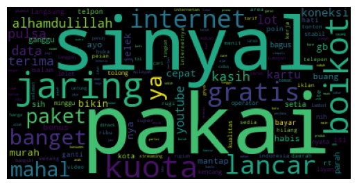

```python
from wordcloud import WordCloud

wordcloud = WordCloud().generate_from_frequencies(term_sum)
plt.imshow(wordcloud)
plt.axis("off")
```

We can change the background color of our wordcloud with the `backgrund_color` parameter.

```
(-0.5, 399.5, 199.5, -0.5)
```

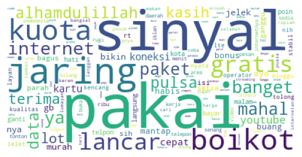

```python
wordcloud = WordCloud(background_color='white').generate_from_frequencies(term_sum)
plt.imshow(wordcloud)
plt.axis("off")
```

To change the color of the words that appear, we can use the `colormap` parameter.

- Color options: [Choosing Colormaps in Matplotlib](https://matplotlib.org/stable/tutorials/colors/colormaps.html)
- Example of color in wordcloud: [Wordcloud - colormap](https://www.kaggle.com/code/niteshhalai/wordcloud-colormap)

```
(-0.5, 399.5, 199.5, -0.5)
```

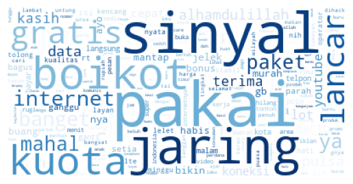

```python
wordcloud = WordCloud(background_color='white', colormap='Blues').generate_from_frequencies(term_sum)
plt.imshow(wordcloud)
plt.axis("off")
```

We can save the wordcloud that we have created into an image file (PNG).

```python
# Save the image in the img folder:
wordcloud.to_file("tweet_wordcloud.png")
```

```
<wordcloud.wordcloud.WordCloud at 0x1f6deffa920>
```

## Cross Validation

*Cross validation* is a resampling procedure used to evaluate machine learning models on limited data samples. The procedure involves dividing the dataset into two subsets.

- Train data: Used to be learned by the model.
- Test data: Used to evaluate the learned machine learning model.

The goal is to estimate the performance of the machine learning model on new data (data not used to train the model). Let's divide it using a proportion of 75:25

```python
from sklearn.model_selection import train_test_split
```

- Feature: docterm (hasil BoW)
- Target: Sentiment

```python
X_train, X_test, y_train, y_test = train_test_split(docterm,
                                                    df['Sentiment'],
                                                    test_size=0.25,
                                                    random_state=123)

print("TRAIN:", X_train.shape)
print("TEST:", X_test.shape)
```

```
TRAIN: (225, 621)
TEST: (75, 621)
```

```python
# checking the data split
print("CLEANED TEXT (feature):", X_train.iloc[0])
print("SENTIMENT (target):", y_train.iloc[0])
```

```
CLEANED TEXT (feature): acara           0
aceh            0
adhan           0
aduh            0
ajaib           0
               ..
youtubenya      0
youtubetahun    0
yoyakarta       0
yuk             0
zalim           0
Name: 107, Length: 621, dtype: int64
SENTIMENT (target): negative
```

```python
df.loc[107, 'text_lower']
```

```
'<provider_name> <provider_name>4glte <provider_name> #bogor #area  <url> … udah 3 bulan tidak ada tanggapan yg jelas '
```

## Model Fitting & Evaluation

This time we will use the Naive Bayes model. Naive Bayes is a lightweight and fast model that gives satisfactory results, especially for text data classification cases.

```python
from sklearn.naive_bayes import BernoulliNB
from sklearn.metrics import accuracy_score

model = BernoulliNB().fit(X_train, y_train)
y_pred = model.predict(X_test)
print('Accuracy:', accuracy_score(y_test, y_pred))
```

```
Accuracy: 0.8266666666666667
```

```python
y_pred
```

```
array(['negative', 'positive', 'negative', 'positive', 'positive',
       'negative', 'negative', 'negative', 'negative', 'negative',
       'negative', 'positive', 'negative', 'negative', 'negative',
       'positive', 'negative', 'negative', 'positive', 'negative',
       'negative', 'positive', 'negative', 'negative', 'negative',
       'positive', 'positive', 'positive', 'negative', 'negative',
       'positive', 'negative', 'negative', 'positive', 'positive',
       'negative', 'negative', 'positive', 'negative', 'negative',
       'positive', 'negative', 'positive', 'positive', 'negative',
       'negative', 'positive', 'negative', 'negative', 'positive',
       'negative', 'negative', 'negative', 'negative', 'negative',
       'positive', 'negative', 'negative', 'negative', 'negative',
       'positive', 'positive', 'positive', 'negative', 'negative',
       'negative', 'negative', 'positive', 'negative', 'negative',
       'negative', 'positive', 'negative', 'positive', 'negative'],
      dtype='<U8')
```

From the evaluation results above, we get an accuracy value of 0.827, which means that our model successfully predicts 83% of tweets correctly.

# Summary